# Background and Context

### XGBoost Classifier

```python
xgb = XGBClassifier(random_state=1,eval_metric='logloss')
xgb.fit(X_train, y_train)
```

```
XGBClassifier(base_score=0.5, booster='gbtree', colsample_bylevel=1,
              colsample_bynode=1, colsample_bytree=1, eval_metric='logloss',
              gamma=0, gpu_id=-1, importance_type='gain',
              interaction_constraints='', learning_rate=0.300000012,
              max_delta_step=0, max_depth=6, min_child_weight=1, missing=nan,
              monotone_constraints='()', n_estimators=100, n_jobs=16,
              num_parallel_tree=1, random_state=1, reg_alpha=0, reg_lambda=1,
              scale_pos_weight=1, subsample=1, tree_method='exact',
              validate_parameters=1, verbosity=None)
```

```
Accuracy on training set :  0.9994153756211634
Accuracy on test set :  0.9229720518064076
Recall on training set :  0.9968944099378882
Recall on test set :  0.6956521739130435
Precision on training set :  1.0
Precision on test set :  0.8687782805429864
F1 score on training set :  0.9984447900466563
F1 score on test set :  0.7726358148893361
```

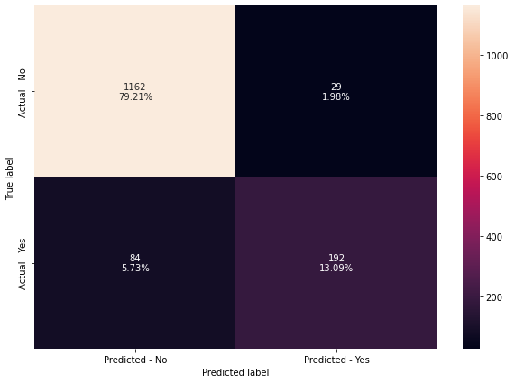

```python
xgb_score=get_metrics_score(xgb)
make_confusion_matrix(xgb,y_test)
```

Given the approximation of the previous methods, stacking them would likely result in better performance without the need of the high computational demand of tuning the XGB Classifier.

### Stacking Classifier

```python
abc_e =  AdaBoostClassifier(random_state=1)
gbc_e = GradientBoostingClassifier(random_state=1)
xbg_e = XGBClassifier(random_state=1,eval_metric = 'logloss')

clf = [('abc',abc_e),('gbc',gbc_e)] #list of (str, estimator)

stack_model_I = StackingClassifier( estimators = clf, final_estimator = xbg_e)

stack_model_I.fit(X_train,y_train)
```

```
StackingClassifier(estimators=[('abc', AdaBoostClassifier(random_state=1)),
                               ('gbc',
                                GradientBoostingClassifier(random_state=1))],
                   final_estimator=XGBClassifier(base_score=None, booster=None,
                                                 colsample_bylevel=None,
                                                 colsample_bynode=None,
                                                 colsample_bytree=None,
                                                 eval_metric='logloss',
                                                 gamma=None, gpu_id=None,
                                                 importance_type='gain',
                                                 interaction_constraints=None,
                                                 learning_rate=None,
                                                 max_delta_step=None,
                                                 max_depth=None,
                                                 min_child_weight=None,
                                                 missing=nan,
                                                 monotone_constraints=None,
                                                 n_estimators=100, n_jobs=None,
                                                 num_parallel_tree=None,
                                                 random_state=1, reg_alpha=None,
                                                 reg_lambda=None,
                                                 scale_pos_weight=None,
                                                 subsample=None,
                                                 tree_method=None,
                                                 validate_parameters=None,
                                                 verbosity=None))
```

```
Accuracy on training set :  0.8775211926337328
Accuracy on test set :  0.858214042263122
Recall on training set :  0.4891304347826087
Recall on test set :  0.4492753623188406
Precision on training set :  0.7777777777777778
Precision on test set :  0.6888888888888889
F1 score on training set :  0.6005719733079123
F1 score on test set :  0.543859649122807
```

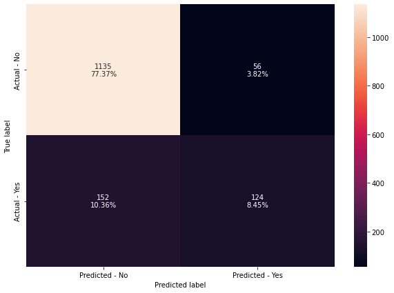

```python
stackI_score = get_metrics_score(stack_model_I)

make_confusion_matrix(stack_model_I,y_test)
```

### Stacking Classifier II

```python
dtc =  DecisionTreeClassifier(random_state=1)
bc = BaggingClassifier(random_state=1)
rfc = RandomForestClassifier(random_state=1)

clf = [('dtc',dtc),('bc',bc)] #list of (str, estimator)

stack_model_II = StackingClassifier( estimators = clf, final_estimator = rfc)

stack_model_II.fit(X_train,y_train)
```

```
StackingClassifier(estimators=[('dtc', DecisionTreeClassifier(random_state=1)),
                               ('bc', BaggingClassifier(random_state=1))],
                   final_estimator=RandomForestClassifier(random_state=1))
```

```
Accuracy on training set :  0.997953814674072
Accuracy on test set :  0.9168370824812543
Recall on training set :  1.0
Recall on test set :  0.7681159420289855
Precision on training set :  0.989247311827957
Precision on test set :  0.7851851851851852
F1 score on training set :  0.9945945945945946
F1 score on test set :  0.7765567765567766
```

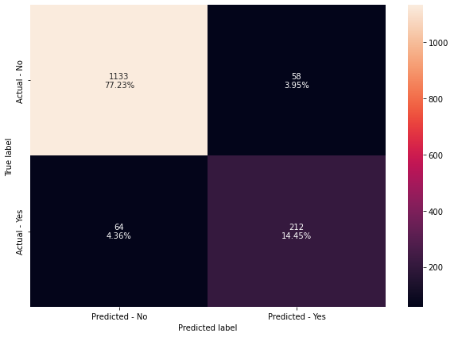

```python
stackII_score = get_metrics_score(stack_model_II)

make_confusion_matrix(stack_model_II,y_test)
```

```python
# defining list of models
models = [abc, gbc, gbc_tuned, xgb, stack_model_I,stack_model_II]

# defining empty lists to add train and test results
acc_train = []
acc_test = []
recall_train = []
recall_test = []
precision_train = []
precision_test = []

# looping through all the models to get the accuracy, precall and precision scores
for model in models:
    j = get_metrics_score(model,False)
    acc_train.append(np.round(j[0],2))
    acc_test.append(np.round(j[1],2))
    recall_train.append(np.round(j[2],2))
    recall_test.append(np.round(j[3],2))
    precision_train.append(np.round(j[4],2))
    precision_test.append(np.round(j[5],2))
```

```python
comparison_frame = pd.DataFrame({'Model':['AdaBoost with default paramters',
                                          'Gradient Boosting with default parameters',
                                          'Gradient Boosting Tuned',
                                          'XGBoost with default parameters',
                                          'Stack Model (AB>GB>>XGB)',
                                          'Stack Model (DT>BC>>RF)'],
                                          'Train_Accuracy': acc_train,'Test_Accuracy': acc_test,
                                          'Train_Recall':recall_train,'Test_Recall':recall_test,
                                          'Train_Precision':precision_train,'Test_Precision':precision_test})
comparison_frame
```

|  | Model | Train_Accuracy | Test_Accuracy | Train_Recall | Test_Recall | Train_Precision | Test_Precision |
| --- | --- | --- | --- | --- | --- | --- | --- |
| 0 | AdaBoost with default paramters | 0.84 | 0.85 | 0.31 | 0.31 | 0.68 | 0.71 |
| 1 | Gradient Boosting with default parameters | 0.88 | 0.86 | 0.44 | 0.39 | 0.88 | 0.78 |
| 2 | Gradient Boosting Tuned | 0.92 | 0.88 | 0.61 | 0.47 | 0.94 | 0.79 |
| 3 | XGBoost with default parameters | 1.00 | 0.92 | 1.00 | 0.70 | 1.00 | 0.87 |
| 4 | Stack Model (AB>GB>>XGB) | 0.88 | 0.86 | 0.49 | 0.45 | 0.78 | 0.69 |
| 5 | Stack Model (DT>BC>>RF) | 1.00 | 0.92 | 1.00 | 0.77 | 0.99 | 0.79 |

Given that the best performance was obtained by an ensemble technique finalizing with a Random Forrest Classifier we can observe the importance of variables based on this classifier.

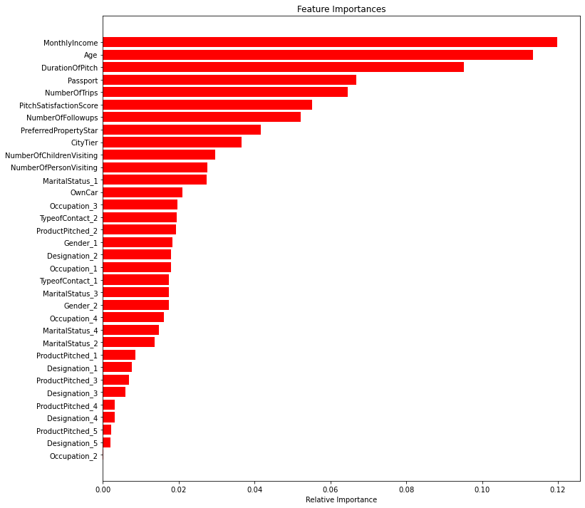

```python
rfc.fit(X_train,y_train)
importances = rfc.feature_importances_
indices = np.argsort(importances)
feature_names = list(X.columns)

plt.figure(figsize=(12,12))
plt.title('Feature Importances')
plt.barh(range(len(indices)), importances[indices], color='red', align='center')
plt.yticks(range(len(indices)), [feature_names[i] for i in indices])
plt.xlabel('Relative Importance')
plt.show()
```

## Business Insights

- Using a Stacking Classifier combining a decision tree, bagging classifier and feeding this to a Random Forest Classifier we reach a fairly good performance of a model despite showing signs of overfitting.
- This model shows around 8% of classifications will be wrong, where ~4% will miss likely customers, and other 4% will target unlikely customers.
- I recommend a discussion with the company to assess losses in terms of how much investment happens for targetting versus missing customers that would buy the package. By defining this precisely, we can further tune the model to minimize financial loss by erring on the financially advantageous side.
- While Recall was used primarily as the metric of interest, during tuning we observe a balancing of performance between both Precision and Recall.
- Further tuning of the XGB classifier model would be recommended only after conversations with the company between metric prioritization to focus tuning efforts between pragmatic intervals

### XGBoost Classifier Tuning

```python
xgb_tuned = XGBClassifier(random_state=1,eval_metric='logloss')

# Grid of parameters to choose from
## add from
parameters = {
    "n_estimators": np.arange(0,100,50),
    "scale_pos_weight":[0,2],
    "subsample":[0.5,0.7,0.9],
    "learning_rate":[0.05,0.1,0.2],
    "gamma":[0,1,3],
    "colsample_bytree":[0.5,0.7,0.9],
    "colsample_bylevel":[0.5,0.7,0.9]
}

# Type of scoring used to compare parameter combinations
acc_scorer = metrics.make_scorer(metrics.recall_score)

# Run the grid search
grid_obj = GridSearchCV(xgb_tuned, parameters,scoring=acc_scorer,cv=5)
grid_obj = grid_obj.fit(X_train, y_train)

# Set the clf to the best combination of parameters
xgb_tuned = grid_obj.best_estimator_

# Fit the best algorithm to the data.
xgb_tuned.fit(X_train, y_train)
```

```python
xgb_tuned_score=get_metrics_score(xgb_tuned)

make_confusion_matrix(xgb_tuned,y_test)
```

[output not shown]

```python
importances = xgb_tuned.feature_importances_
indices = np.argsort(importances)
feature_names = list(X.columns)

plt.figure(figsize=(12,12))
plt.title('Feature Importances')
plt.barh(range(len(indices)), importances[indices], color='red', align='center')
plt.yticks(range(len(indices)), [feature_names[i] for i in indices])
plt.xlabel('Relative Importance')
plt.show()
```

[output not shown]